# Belt and Road Initiative Investment Stat in MENA

Ruoqi Zhang

4/8/2019

## Description of Data

American Enterprise Institute’s China Global Investment Tracker (CGIT) is the only publicly available dataset recording China’s global investment. It contains both BRI and non-BRI investments around the world. It also provides details of those investments, including country, participating companies, size of the investment, and the sector of the investment.

For the purpose of this research project, we are interested in BRI-related investment projects in select countries involved in BRI.

## Total Investment Table

To get a better sense of the countries we are exploring, we use gt to list the volumn of BRI investments and construction projects since 2013.

Belt and Road Initiative Investments in Middle East

Aggregate investment in million dollars, 2013-2018

| Country | 2013 | 2014 | 2015 | 2016 | 2017 | 2018 | Total Investment |
| --- | --- | --- | --- | --- | --- | --- | --- |
| UAE | $0 M | $640 M | $760 M | $4,150 M | $7,730 M | $7,940 M | $21,220 M |
| Egypt | $0 M | $370 M | $1,780 M | $1,970 M | $3,630 M | $7,940 M | $15,690 M |
| Saudi Arabia | $190 M | $4,260 M | $2,020 M | $1,250 M | $1,910 M | $4,390 M | $14,020 M |
| Iran | $0 M | $1,010 M | $500 M | $5,260 M | $4,120 M | $2,080 M | $12,970 M |
| Iraq | $1,580 M | $1,590 M | $670 M | $1,800 M | $450 M | $1,830 M | $7,920 M |
| Kuwait | $0 M | $240 M | $2,480 M | $1,620 M | $1,330 M | $2,070 M | $7,740 M |
| Algeria | $1,690 M | $2,130 M | $410 M | $3,350 M | $0 M | $0 M | $7,580 M |
| Jordan | $270 M | $1,600 M | $350 M | $1,300 M | $380 M | $500 M | $4,400 M |
| Turkey | $0 M | $320 M | $1,560 M | $870 M | $1,090 M | $300 M | $4,140 M |
| Oman | $0 M | $0 M | $300 M | $2,870 M | $0 M | $320 M | $3,490 M |
| Qatar | $0 M | $560 M | $1,400 M | $1,110 M | $0 M | $230 M | $3,300 M |
| Morocco | $0 M | $0 M | $0 M | $0 M | $870 M | $0 M | $870 M |
| Yemen | $510 M | $0 M | $0 M | $0 M | $0 M | $0 M | $510 M |

Source: China Global Investment Tracker/American Enterprise Institute

## Trend of BRI

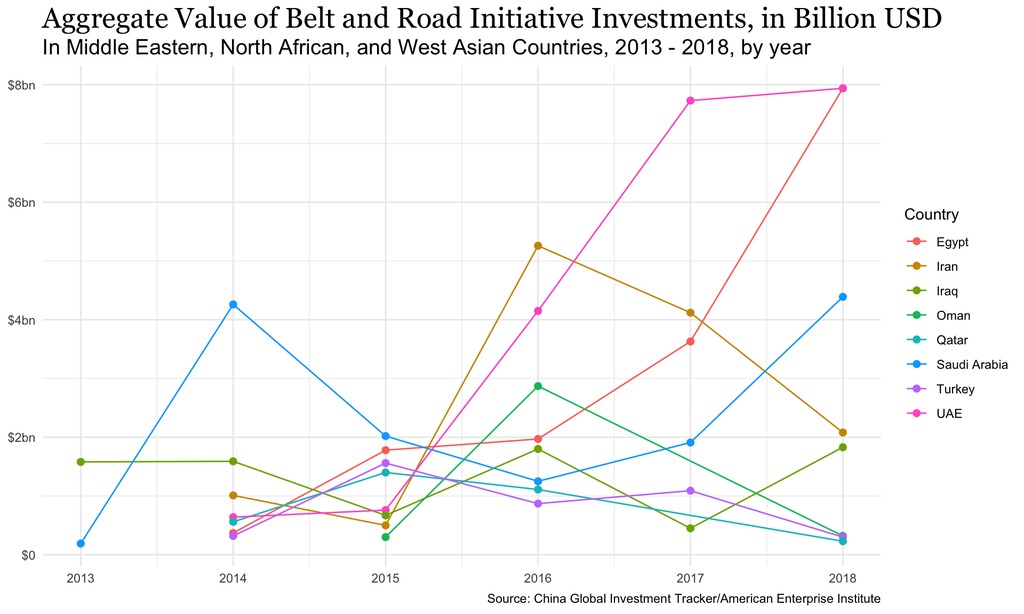

We are also interested in some particular countries’ investment volume through the Belt and Road Initiative, we plot out their trends here:

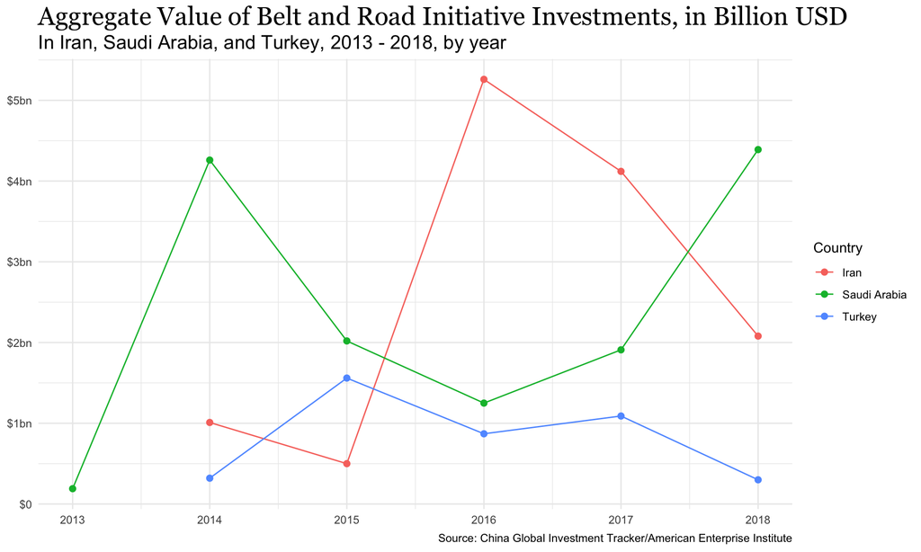

## Case Study: Turkey

Turkey is an interesting case, because it’s the only country that openly condemned China’s religious policies in XUAR. But does it necessarily impact BRI relations between both countries? Note that there is a massive protest against Chinese investments in 2015.

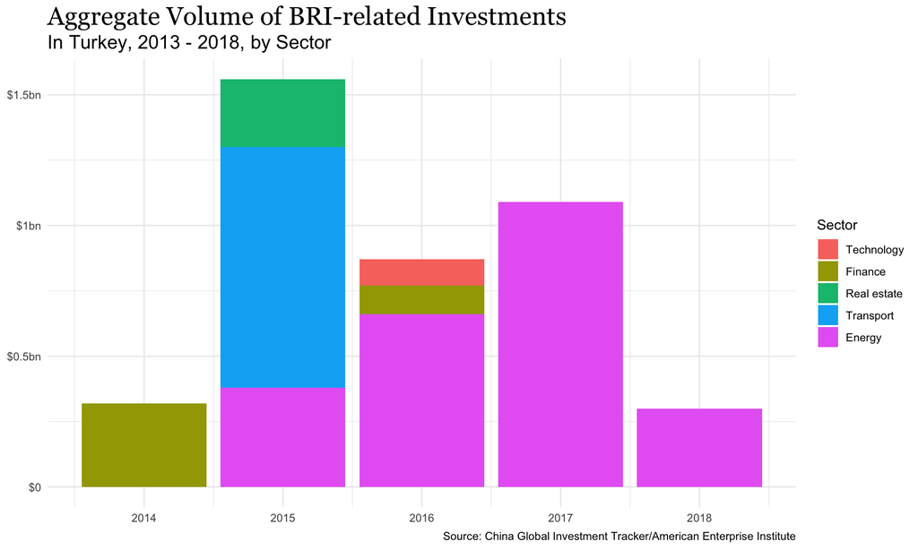